# ManyFaces pilot ratings

Data prep: data cleaning and exclusions

```r
library(tidyverse)
```

## Project Structure

Read in the full project structure from the project file to map experiment names to numbers.

```r
proj <- jsonlite::read_json("data/project_1136_structure.json")

exp_data <- purrr::map_df(proj, \(comp) {
  if (comp$component_type == "exp") {
     data.frame(
       exp_id = comp$id,
       name = comp$name,
       res_name = comp$res_name,
       instructions = comp$instructions,
       question = comp$question,
       exptype = comp$exptype,
       trial_order = comp$trial_order,
       total_stim = comp$total_stim,
       random_stim = comp$random_stim,
       trials = length(comp$trial),
       stim = length(comp$stim)
     )
  } else {
    NULL
  }
}) |>
  mutate(exp = sub("ManyFaces? Pilot Ratings: ", "", res_name) |> trimws())


trial_data <- purrr::map_df(proj, \(comp) {
  if (comp$component_type == "exp") {
    purrr::map_df(comp$trial, \(trial) {
      data.frame(
        exp_id = comp$id,
        n = trial$trial_n,
        name = trial$name,
        img_id = trial$center_img,
        img_path = comp$stimuli[[as.character(trial$center_img)]]
      )
    })
  } else {
    NULL
  }
}) |>
  mutate(name = sub("^(manyfaces|attention_checks)/", "", name))
```

```r
exp_data |>
  select(exp_id, exp, question, trials) |>
  arrange(exp)
```

| exp_id | exp | question | trials |
| --- | --- | --- | --- |
| 1400 | age | How old does this person look? | 212 |
| 1386 | anger | How intensely is this person expressing anger? | 194 |
| 1377 | attractive | How attractive does this person look? | 212 |
| 1397 | attractive (unstd) | How attractive does this person look? | 195 |
| 1387 | disgust | How intensely is this person expressing disgust? | 191 |
| 1379 | dominant | How dominant does this person look? | 212 |
| 1398 | dominant (unstd) | How dominant does this person look? | 195 |
| 1384 | emotion 1 | What emotion is this person expressing? | 186 |
| 1401 | emotion 2 | What emotion is this person expressing? | 195 |
| 1402 | emotion 3 | What emotion is this person expressing? | 189 |

[output cut: 11 more lines]

## Data Prep

### Raw Data

This workflow requires the data-raw directory, which is not shared on github.

This is the SQL for downloading the data from Experimentum. We need to download in chunks of 50000 rows to avoid file download limits on the site (not needed if downloading directly from SQL).

```sql
SELECT
  session.id as session_id, project_id, exp.res_name as exp_name, exp_id,
  session.user_id, user.sex as user_sex, user.status as user_status,
  ROUND(DATEDIFF(ed.dt, REPLACE(birthday, "-00","-01"))/365.25, 1) AS user_age,
  trial.name as trial_name,
  trial_n,
  `order`,
  dv,
  rt,
  ed.side,
  ed.dt
FROM session
  LEFT JOIN user USING (user_id)
  LEFT JOIN exp_data AS ed ON ed.session_id = session.id
  LEFT JOIN exp ON exp.id = ed.exp_id
  LEFT JOIN trial USING (exp_id, trial_n)
WHERE session.project_id = 1136
  AND user.status IN ("guest", "registered")
  AND exp_id IN (1384, 1400, 1399, 1398, 1401, 1402, 1403,
                 1404, 1405, 1397, 1390, 1389, 1388, 1387,
                 1386, 1385, 1382, 1381, 1380, 1379, 1377)
LIMIT 50000
OFFSET 0
```

```r
# combine multiple downloads into one file
exp_raw <- list.files("data-raw/exp", full.names = TRUE) |>
  read_csv(show_col_types = FALSE) |>
  unique() |>
  filter(user_status %in% c("guest", "registered"))

write_csv(exp_raw, paste0("data-raw/ManyFaces-Pilot-Ratings-exps_", Sys.Date(), ".csv"))

# get most recent files
exp_file <- list.files("data-raw", "ManyFaces-Pilot-Ratings-exps",
                       full.names = TRUE) |>
  sort(decreasing = TRUE) |>
  pluck(1)

exp_raw <- read_csv(exp_file, show_col_types = FALSE) |>
  filter(user_status %in% c("guest", "registered")) |>
  unique()

# get most recent files
quest_file <- list.files("data-raw", "ManyFaces-Pilot-Ratings-quests",
                       full.names = TRUE) |>
  sort(decreasing = TRUE) |>
  pluck(1)

quest_raw <- read_csv(quest_file, show_col_types = FALSE) |>
  filter(user_status %in% c("guest", "registered")) |>
  unique()

# write to the data directory
write_csv(exp_raw, "data/manyfaces-pilot-exp.csv")
write_csv(quest_raw, "data/manyfaces-pilot-quest.csv")
```

### Reshape Data

```r
exp_raw <- read_csv("data/manyfaces-pilot-exp.csv",
                    show_col_types = FALSE)

ed <- exp_data |>
  select(exp_id, exp, trials) |>
  rename(trials_total = trials)

exp_long_raw <- exp_raw |>
  select(session_id, exp_id, trial_name, dv, rt, dt) |>
  unique() |>
  mutate(trial_name = sub("^(manyfaces|attention_checks)/", "", trial_name)) |>
  left_join(ed, by = "exp_id")
```

```r
quest_raw <- read_csv("data/manyfaces-pilot-quest.csv",
                      show_col_types = FALSE) |>
  dplyr::select(session_id, q_name, dv, endtime) |>
  unique() |>
  pivot_wider(names_from = q_name, values_from = dv) |>
  mutate(age = as.integer(age))
```

```r
model_raw <- read_csv("data/manyfaces-pilot-models.csv",
                      show_col_types = FALSE)
```

### Preliminary data cleaning

#### Model data

```r
ethnicity_recode <- read_csv("data/eth_recode.csv", na = "", show_col_types = FALSE)
gender_recode <- read_csv("data/gender_recode.csv", na = "", show_col_types = FALSE)
```

```r
data_model <- model_raw |>
  separate_wider_delim(ID,
                       delim = "_",
                       names = c("lab_id", "model_id"),
                       too_many = "drop") |>
  mutate(across(where(is.character), ~ na_if(.x, "NULL"))) |>
  # recode gender and ethnicity
  mutate(gender = tolower(gender),
         ethnicity = tolower(ethnicity)) |>
  left_join(gender_recode, by = "gender") |>
  left_join(ethnicity_recode, by = "ethnicity") |>
  relocate(gender_rec, .after = gender) |>
  relocate(ethnicity_rec, .after = ethnicity) |>
  # recode height and weight
  # one person reported weight of 37 kg at 163 cm -- recode as NA? Would be a BMI of 13.9
  mutate(height_cm = case_when(height_units == "cm" & as.numeric(height) < 100 ~ as.numeric(height) * 2.54, # likely mislabelled inches
                               height_units == "in" & as.numeric(height) > 100 ~ as.numeric(height), # likely mislabelled cms
                               height_units == "in" ~ as.numeric(height) * 2.54,
                               height_units == "cm" ~ as.numeric(height),
                               .default = NA_real_),
         weight_kg = case_when(as.numeric(weight) == 0 ~ NA_real_,
                               # Note: one participant indicated weight as 37kg and height as 163cm, which would mean BMI of ~14.0 - data entry error or legitimate value?
                               weight_units == "lb" & as.numeric(weight) < 80 ~ as.numeric(weight),            # likely mislabelled kg
                               weight_units == "lb" ~ as.numeric(weight) / 2.20462,
                               weight_units == "kg" ~ as.numeric(weight),
                               as.numeric(weight) == 0 ~ NA,
                               .default = NA_real_)) |>
  relocate(height_cm, .after = height_units) |>
  relocate(c(weight, weight_units, weight_kg), .after = height_cm)
```

#### Questionnaire data

```r
quest_eth_recode <- read_csv("data/quest_eth_recode.csv", na = "", show_col_types = FALSE)

data_quest <- quest_raw |>
  # recode ethnicity
  mutate(ethnicity = tolower(ethnicity)) |>
  left_join(quest_eth_recode, by = "ethnicity") |>
  relocate(ethnicity_rec, .after = ethnicity)
```

#### Experimental data

**Remove duplicate trials and incomplete data**

We start with 2115 participants completing a total of 2158 experiments.

Some participants completed more than the maximum amount of trials in an experiment. Duplicate trials were removed by only retaining participants’ initial ratings of a particular stimulus.

```r
dupl_trials_rm <- exp_long_raw |>
  arrange(session_id, exp_id, trial_name, trials_total, dt) |>
  distinct(session_id, exp_id, trial_name, trials_total, .keep_all = TRUE)
```

```r
incomplete <- dupl_trials_rm |>
  count(session_id, exp_id, trials_total) |>
  filter(n < trials_total)

complete <- dupl_trials_rm |>
  filter(!session_id %in% incomplete$session_id)
```

179 participants did not complete all trials for a total of 190 experiments.

```r
dupl_exp_ids <- complete |>
  # Mark participants that participated twice and establish which exp they did first
  group_by(session_id, exp_id) |>
  summarise(first_dt = min(dt), .groups = "drop") |>
  group_by(session_id) |>
  mutate(n_exp = n()) |>
  mutate(first_exp = exp_id[which.min(first_dt)]) |>
  ungroup() |>
  filter(n_exp > 1 & exp_id != first_exp)
```

```r
exp_long <- complete |>
   anti_join(dupl_exp_ids, by = c("session_id", "exp_id" = "first_exp"))
```

Prior to pre-registered exclusions, preliminary sample thus consisted of 1936 participants.

```r
# Rating data prior to exclusions
write_csv(exp_long, "data/manyfaces-pilot-exp-prior-exclusions.csv")
```

### Pre-registered exclusions

#### Overly consistent responses

Participants were excluded based on overly consistent responding, i.e. if they responded to at least 90% of trials identically. Please note that four additional participants with only two unique responses across all trials were identified during reliability analyses and excluded under the original ‘overly consistent responding’ criterion.

```r
overly_consistent_prereg <- exp_long |>
  filter(!startsWith(trial_name, "check_")) |>
  summarise(
    same_pcnt = max(tabulate(match(dv, unique(dv)))) / n(),
    .by = c(session_id, exp_id)) |>
  dplyr::select(session_id, exp_id, same_pcnt) |>
  filter(same_pcnt >= 0.90)
```

```r
overly_consistent_additional <- exp_long |>
  filter(!startsWith(trial_name, "check_")) |>
  summarise(
    n_unique = n_distinct(dv, na.rm = TRUE),
    .by = c(session_id, exp_id)) |>
  dplyr::select(session_id, exp_id, n_unique) |>
  filter(n_unique <= 2)
```

```r
overly_consistent <- overly_consistent_prereg |>
  full_join(overly_consistent_additional, by=c("session_id", "exp_id"))
```

#### Overly fast responses

Participants were excluded based on overly fast responding, i.e. if their median reaction time fell below the 1st percentile of the overall distribution of median reaction times.

```r
med_rt <- exp_long |>
  summarise(med_rt = median(rt),
            .by = c(session_id, exp_id))

overly_fast <- med_rt |>
  filter(med_rt < quantile(med_rt, probs = 0.01))
```

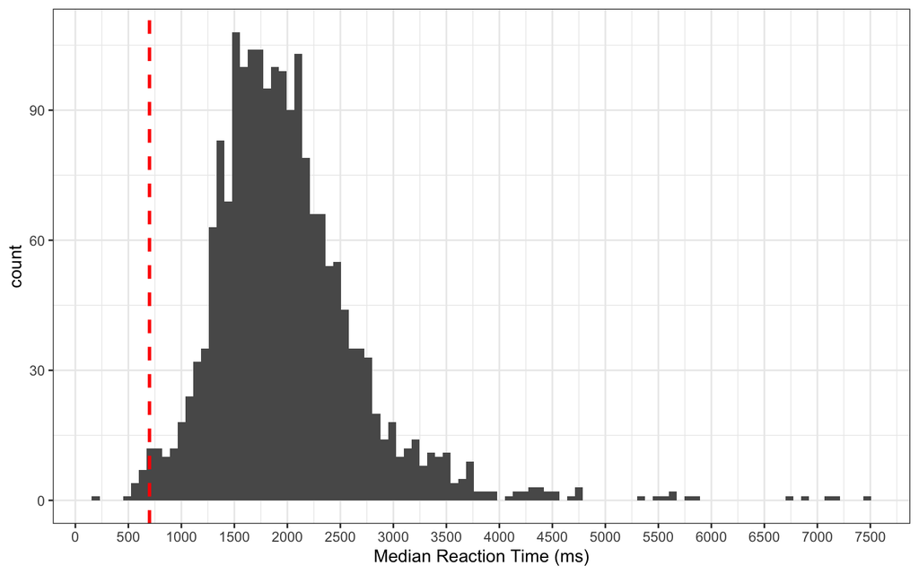

```r
med_rt |>
  ggplot(aes(x = med_rt)) +
  geom_histogram(bins = 100) +
  geom_vline(xintercept = quantile(med_rt$med_rt, probs = 0.01),
             color = "red", linetype = "dashed", linewidth = 1) +
  scale_x_continuous(breaks = seq(0, 10000, 500)) +
  labs(x = "Median Reaction Time (ms)") +
  theme_bw()
```

#### Self-reported honesty check

Participants were excluded based on self-reported honesty check, i.e. if they responded not taking the study seriously vs. taking it authentically.

```r
honesty_check_failed <- data_quest |>
  select(session_id, honesty_check = try) |>
  unique() |>
  filter(honesty_check != 2)
```

#### Attention checks

Participants were excluded if they failed two or more attention checks.

```r
attn_checks_failed <- exp_long |>
  select(session_id:dv) |>
  filter(grepl("check", trial_name)) |>
  mutate(check_type = sub("check_[a-z0-9-]+_", "", trial_name),
         check_type = ifelse(exp_id == 1400, substr(check_type, 4, 6), check_type)) |>
  summarise(attn_checks_passed = mean(check_type == dv),
            .by = c("session_id", "exp_id")) |>
  filter(attn_checks_passed < 6/7)
```

#### Overview of exclusions

```r
exclusions <- overly_consistent |>
  full_join(overly_fast, by = c("session_id", "exp_id")) |>
  full_join(honesty_check_failed, by = c("session_id")) |>
  full_join(attn_checks_failed, by = c("session_id", "exp_id"))
```

```r
exclusions |>
  summarise(
    `Overly consistent response` = sum(!is.na(same_pcnt)),
    `RT below cutoff` = sum(!is.na(med_rt)),
    `Failed honesty check` = sum(!is.na(honesty_check)),
    `Failed more than 1 of 7 attention checks` = sum(!is.na(attn_checks_passed)),
    "Total exclusions" = n()
  ) |>
  pivot_longer(
    cols = everything(),
    names_to = "Reason for exclusion",
    values_to = "Number of participants"
  )
```

| Reason for exclusion | Number of participants |
| --- | --- |
| Overly consistent response | 13 |
| RT below cutoff | 20 |
| Failed honesty check | 2 |
| Failed more than 1 of 7 attention checks | 19 |
| Total exclusions | 49 |

Please note that multiple participants met more than one exclusion criterion (e.g., responded too quickly and failed attention checks); therefore, the counts for individual criteria do not sum to the total number of participants excluded.

Exclude 49 participants and remove attention checks from data.

```r
data_exp <- exp_long |>
  anti_join(exclusions, by = "session_id") |>
  filter(!grepl("check_", trial_name))
```

After exclusions, there were 1887 participants.

Number of participants per study:

```r
data_exp |>
  summarise(.by = c(exp, session_id)) |>
  count(exp)
```

| exp | n |
| --- | --- |
| age | 85 |
| anger | 84 |
| attractive | 84 |
| attractive (unstd) | 84 |
| disgust | 91 |
| dominant | 91 |
| dominant (unstd) | 94 |
| emotion 1 | 97 |
| emotion 2 | 87 |
| emotion 3 | 88 |

[output cut: 11 more lines]

### Compile and save data

```r
# Rating data
write_csv(data_exp, "data/manyfaces-pilot-exp_cleaned.csv")

# Questionnaire data
data_quest |>
  filter(session_id %in% data_exp$session_id) |>
  write_csv("data/manyfaces-pilot-quest_cleaned.csv")

# Exclusions data
write_csv(exclusions, "data/exclusions.csv")

# Model data
write_csv(data_model, "data/manyfaces-pilot-models_cleaned.csv")
```